# Biological Network from RNA-Sequencing

Author

Vincenzo della Gatta

Published

October 19, 2026

## Data download from Linked Omics

**Liver** cancer RNA-Seq data

```r
#data_rna10 <- TCGAbiolinks::getLinkedOmicsData(project = "TCGA-LIHC", dataset = "RNAseq (HiSeq, Gene level)")

#saveRDS(data_rna10, "Liver_rna.rds")

data_rna = readRDS("Liver_rna.rds")
```

### Dataset

```r
head(data_rna[,1:7])
```

```
  attrib_name TCGA.2V.A95S TCGA.2Y.A9GS TCGA.2Y.A9GT TCGA.2Y.A9GU TCGA.2Y.A9GV
1        A1BG      14.4437      14.4668      16.2451      13.1867      16.3623
2        A1CF       9.1902      10.6199      10.3235      10.2912      10.6807
3       A2BP1       0.0000       1.7926       0.0000       0.0000       0.0000
4       A2LD1       8.5540       6.6384       7.7493      11.5089       8.6610
5       A2ML1       0.0000       0.0000       0.9235       1.4159       0.0000
6         A2M      18.1273      14.9278      14.2524      17.8962      13.0961
  TCGA.2Y.A9GW
1      16.1567
2      10.4749
3       0.0000
4       8.0803
5       0.0000
6      15.4191
```

## Data pre-processing

### Selection of expressed genes

Selection of patient columns:

```r
library(dplyr)

rna_samples <- data_rna %>%
  select(-attrib_name)
```

Calculate mean expression for each gene:

```r
mean_expression <- rowMeans(rna_samples, na.rm = TRUE)
```

Remotion of genes with mean expression $<$ 10

```r
rna_mean_filtered <- data_rna[mean_expression >= 10, ]

rna_samples_filtered <- rna_samples[mean_expression >= 10, ]
```

### Selection of most variable genes

Selection of most informative genes across all the patients.

- Use of `Coefficient of Variation`

```r
#Calculate the coefficient of variation (CV)
gene_mean <- rowMeans(rna_samples_filtered, na.rm = TRUE)

gene_sd <- apply(
  rna_samples_filtered,
  1,
  sd,
  na.rm = TRUE
)

cv <- gene_sd / gene_mean
```

Rank genes from highest to lowest CV:

```r
gene_order <- order(
  cv,
  decreasing = TRUE,
  na.last = NA)
```

Keep the top 20% most variable genes

```r
n_top <- ceiling(length(gene_order) * 0.20)

selected_genes <- head(gene_order, n_top)

rna_filtered <- rna_mean_filtered[selected_genes, ]
```

## Network construction

The **RNA network** was constructed using **Pearson correlation**:

- **Nodes:** patients
- **Edges:** pairwise similarity
- **Threshold:** only the **top 15%** of similarities were retained

### Similarity of patient

Compute Pearson correlation between patients

- Use of the `cor()` function

```r
library(igraph)

rna_data <- rna_filtered[, 2:372]

rna_similarity <- cor(
  rna_data,
  method = "pearson")

diag(rna_similarity) <- 0 #no self loops
```

### Creation of edgelist

We can select the lower triangle of the similarity matrix, beacause correlation is simmetric. We don’t consider the diagonal, because of self loops.

```r
edge_index <- which(
  lower.tri(rna_similarity, diag = FALSE),
  arr.ind = TRUE)

head(edge_index)
```

```
     row col
[1,]   2   1
[2,]   3   1
[3,]   4   1
[4,]   5   1
[5,]   6   1
[6,]   7   1
```

```r
#lower.tri() returns TRUE for those located below the main diagonal.

#which() finds all cells that contain TRUE, and arr.ind = TRUE returns two numbers: the row and the column.

#In this way we have a matrix that tells you where to retrieve the values corresponding to the pairs.
```

Construction of a dataframe that contains the pairs similarity:

```r
rna_all_edges <- data.frame(
  from = colnames(rna_similarity)[edge_index[, 1]],
  to = colnames(rna_similarity)[edge_index[, 2]],
  weight = rna_similarity[edge_index])
#in this way we can have dataframe that has an edgelist form
```

We don’t want a complete graph. We define a **similarity threshold**: patients, below which the edge weight is set to **0**.

- The 85th quantile is selected with `quantile()` function.

```r
similarities <- rna_similarity[lower.tri(rna_similarity)]

threshold <- quantile(
  similarities,
  0.85,
  na.rm = TRUE
)
```

Keep only similarities above the threshold.

- Similarities under the threshold are forced to 0.

```r
rna_adjacency <- rna_similarity

rna_adjacency[rna_adjacency < threshold] <- 0

diag(rna_adjacency) <- 0
```

Weighted RNA network with ‘igraph’.

```r
rna_graph <- graph_from_adjacency_matrix(
  rna_adjacency,
  mode = "upper",
  diag = FALSE,
  weighted = TRUE
)

rna_graph <- delete_edges(
  rna_graph,
  E(rna_graph)[E(rna_graph)$weight == 0])
```

### Graph edge weights distribution

We can build a histogram of the edge weights starting from an igraph object.

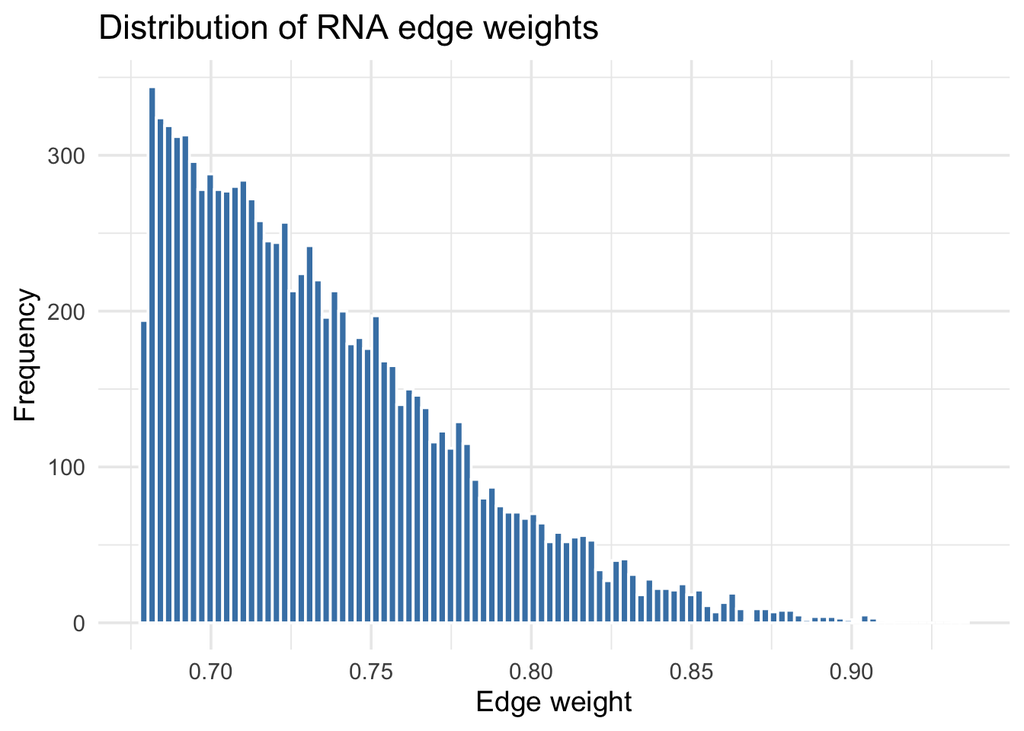

```r
library(ggplot2)
ggplot(
  data.frame(weight = E(rna_graph)$weight),
  aes(x = weight)
) +
  geom_histogram(bins = 100, fill = "steelblue", color = "white") +
  labs(
    x = "Edge weight",
    y = "Frequency",
    title = "Distribution of RNA edge weights"
  ) +
  theme_minimal(base_size = 14)
```

## Comparison of the network communities

- At increasing levels of graph perturbation, communities are detected and compared with those of the original unperturbed graph, generating a robustness curve.

```r
library(robin)

graph = rna_graph

comparison = robinCompare(graph=graph, method1="walktrap", method2="louvain")
```

```
[1] "Weighted Network Parallel Function"
Detected robin method type independent
It can take time ... It depends on the size of the network.
```

### Plot of the comparison

Louvain communities are more stable, becasuse its curve has a lower VI index. VI quantifies the differences between the community structures detected by the same method on the original and perturbed graphs, with lower values indicating greater stability.

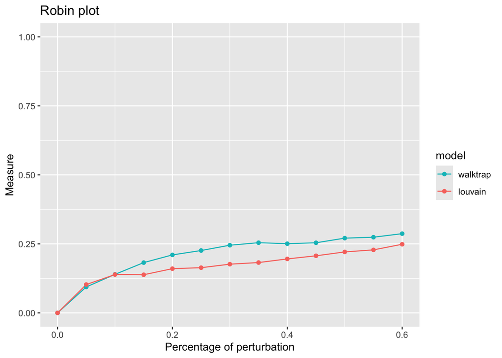

```r
plot(comparison)
```

## Robustness of the network communities

Are **Louvain communities** more robust than the **null model**?

Creation of the null model

```r
graphRandom <- random(graph=graph)
```

Comparison between null model and Louvain model

```r
#robust <- robinRobust(graph=graph, graphRandom=graphRandom, method="louvain")
```

```r
#plot(robust)
```

# Alternative Graph construction

We can use **Cosine similarity** to build an adjacency matrix.

```r
library(lsa)

rna_data <- rna_filtered[, 2:372]

rna_cosine_similarity <- lsa::cosine(
  as.matrix(rna_data)
)

diag(rna_cosine_similarity) <- 0 # No self-loops
```

## Creation od edgelist

```r
edge_index_cosine <- which(
  lower.tri(rna_cosine_similarity, diag = FALSE),
  arr.ind = TRUE
)

rna_cosine_all_edges <- data.frame(
  from = colnames(rna_cosine_similarity)[edge_index_cosine[, 1]],
  to = colnames(rna_cosine_similarity)[edge_index_cosine[, 2]],
  weight = rna_cosine_similarity[edge_index_cosine]
)

head(rna_cosine_all_edges)
```

```
          from           to    weight
1 TCGA.2Y.A9GS TCGA.2V.A95S 0.9814438
2 TCGA.2Y.A9GT TCGA.2V.A95S 0.9758036
3 TCGA.2Y.A9GU TCGA.2V.A95S 0.9730211
4 TCGA.2Y.A9GV TCGA.2V.A95S 0.9757893
5 TCGA.2Y.A9GW TCGA.2V.A95S 0.9849762
6 TCGA.2Y.A9GX TCGA.2V.A95S 0.9834999
```

## Similarity threshold

```r
cosine_similarities <- rna_cosine_similarity[
  lower.tri(rna_cosine_similarity)
]

threshold_cosine <- quantile(
  cosine_similarities,
  0.85,
  na.rm = TRUE
)
```

Keep only similarities above the threshold.

```r
rna_cosine_adjacency <- rna_cosine_similarity

rna_cosine_adjacency[
  rna_cosine_adjacency < threshold_cosine
] <- 0

diag(rna_cosine_adjacency) <- 0
```

Graph construction:

```r
rna_cosine_graph <- graph_from_adjacency_matrix(
  rna_cosine_adjacency,
  mode = "upper",
  diag = FALSE,
  weighted = TRUE
)

rna_cosine_graph <- delete_edges(
  rna_cosine_graph,
  E(rna_cosine_graph)[E(rna_cosine_graph)$weight == 0]
)
```

# Distribution comparison

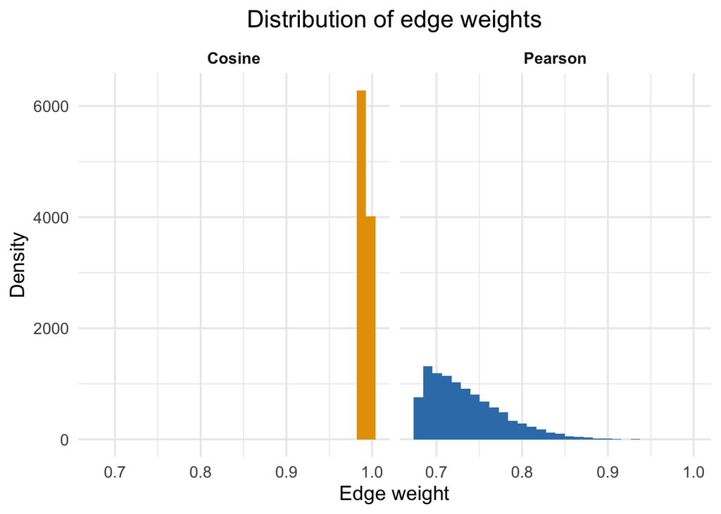

```r
#Edge weights
df_weights <- rbind(
  data.frame(
    Weight = E(rna_graph)$weight,
    Method = "Pearson"
  ),
  data.frame(
    Weight = E(rna_cosine_graph)$weight,
    Method = "Cosine"
  )
)

#Density plots
ggplot(df_weights, aes(x = Weight, fill = Method)) +
  geom_histogram() +
  facet_wrap(~ Method, nrow = 1) +
  scale_fill_manual(values = c(
    "Pearson" = "#377EB8",
    "Cosine" = "#E69F00"
  )) +
  labs(
    x = "Edge weight",
    y = "Density",
    title = "Distribution of edge weights"
  ) +
  theme_minimal(base_size = 14) +
  theme(
    legend.position = "none",
    strip.text = element_text(face = "bold"),
    plot.title = element_text(hjust = 0.5)
  )
```